# Demo 1: Biomedical & Clinical Informatics

Merrimack College DSE6630: Healthcare & Life Sciences Analytics

epsilon : Desi Spark (DS), Elizabeth Greenan (EG), Meghan Holden (MH)

20 May 2026

# Introduction

You have just been brought on as a data science consultant for a patient advocacy watchdog. They have asked you to source information about hospital readmissions, because they would like to flag specific geographic areas or types of hospitals where hospital readmission is unexpectedly high. They have heard that datasets exist to investigate these types of questions, but they are not really sure where to begin.

You remember this one data science class you took - and the dataset from the **Centers for Medicare & Medicaid Services** managed by [Medicare.gov](https://www.medicare.gov). You start poking around the [Hospitals](https://data.cms.gov/provider-data/topics/hospitals) dataset and decide it is exactly what you need.

The problem is, this dataset is massive, so you are not only tasked with identifying a reasonable question you can ask from the dataset but managing the cleaning, pre-processing, and exploratory data analysis on the merged datasets you choose to explore.

## Question

For **Project 1**, you are going to choose your own question! But for this demo analysis, we are focusing on **pneumonia-related hospital readmissions**.

### Why pneumonia-related readmissions?

Hospital readmission rates for patients with pneumonia is almost unbelievably high, with about $\frac{1}{5}$ or 20% of patients hospitalized with pneumonia re-admitted within 30 days (de Alba and Amin, 2014). Further, pneumonia is both a leading cause of death among the elderly as well as a commonly communicated disease in hospitals (as in, people may come into a hospital for a different condition but be readmitted for pneumonia). Thus, given that pneumonia is the only communicable disease on this list, it is serving as our best proxy for diseases spread person-to-person within hospitals because of lack of availability.

#### Our research question:

Can we predict pneumonia-related hospital readmissions and, more generally, disease transfer within hospitals, based on hospital-level characteristics, including patient-ratings, Medicare money received, and other indicators of general performance in disease diagnosis and prevention?

#### Our hypothesis & prediction:

Hospitals are, by their very nature, hot zones for increased spread of disease, including pneumonia. We hypothesize that hospitals with lower indicators of patient care performance and lower Medicare funding rates will generally be unable to provide sufficient control of specific disease diagnosis and prevention, like pneumonia. This is because the same intrinsic and extrinsic factors that impact general patient quality of care is likely to extend to pneumonia, a *common, preventable, and treatable* disease. Thus, we specifically predict that factors indicating lower quality-of-care will predict higher than average rates of pneumonia-related hospital readmissions.

## Objective

Our objective for the patient advocacy watchdog is clean, merge, explore, and predict which hospitals tend to have higher-than-average rates of pneumonia-related readmissions. This is to enable the watchdog group to put together a dashboard or otherwise deploy this information to share with patients so they know how their local hospitals are performing, allowing them to make healthier, more informed choices.

# Data & Data Cleaning

1. Download the [Hospitals](https://drive.google.com/drive/u/0/folders/1Z8VloDDl3_Gl9LhTQyxOS4v34r7xvkgq) dataset as a zip directory. NOTE: These 2024 and 2025 data were originally downloaded from the [CMS repository](https://data.cms.gov/provider-data/topics/hospitals). **Make sure to download it to your local machine NOT your GitHub repo!** I have given you both years’ data, but for now we are still using *2024*. All archived datasets are found [here](https://data.cms.gov/provider-data/archived-data/hospitals).
2. Unzip the directory.
3. Make sure to adjust the name and/or path of the directory in your directory if it is different from mine. *Note that mine is living on my Desktop.*

**WARNING!** Do not try to put these data onto GitHub. They are too large to push. If you need help adjusting your path or have questions, please let me know.

```r
## Make sure to adjust your path!

#filepath <- "~/Desktop/hospitals_current_data_FY2024/"
filepath <- "C:/Users/User/Documents/DSE6630/hospitals_current_data_FY2024/"
```

### Read in the hospital-level data iteratively, while dynamically naming & storing each file as a dataframe.

You may have to dig through the accompanying data dictionary **HOSPITAL_Data_Dictionary.pdf** to get a better handle on what is in the hospital-level files.

##### **Question 1**: [1 point]

Take a look at the chunk below, which performs **dynamic variable assignment** as it reads in each of the files. Your task is to add a comment to each line of code to describe what that line does.

> Your answer in the code chunk as comments. Make sure to use the `#` sign!

```r
#DS, EG, MH
files <- list.files(path = filepath, pattern = "Hospital.csv")  # adds list of files from 'filepath' to object 'files' if file name contains "Hospital.csv"

for(f in 1:length(files)) { # loop for each file index do the following
    dat <- read_csv(paste0(filepath, files[f]), # create dataframe called 'dat' of the csv file from 'files'
                    show_col_types = FALSE, # suppress column type message
                    ## HOT FIX of the "N/A" characters that were problematic
                    na = c("", "NA", "N/A", "Not Applicable", "Not Available","NULL", ".") #Note: added not applicable and not available
                    ) %>%
        clean_names(case = "upper_camel") %>% #converts column names into UpperCamelCase

        ## HOT FIX to convert character to numeric
        type_convert() %>%
        ## HOT FIX to convert date columns based on month/day/year
        mutate(across(contains("Date"), ~ mdy(.)))

    filename <- gsub(".Hospital\\.csv", "", files[f]) # creates 'filename' object removing "Hospital.csv" and one prior character (_,-.) from respective indexed 'files'
    assign(filename, dat) # assign `filename` to `dat` dataframe
}

files <- gsub(".Hospital\\.csv", "", files) %>% data.frame() # create dataframe "files" from list "files". Remove "Hospital.csv" and one prior character (_,-.) from respective 'files'
names(files) <- "File Name" # rename column "File Name"
```

#### Now, let’s look at a list of the files that we’ve read in:

Table 1. List of hospital-level data files.

| File Name |
| --- |
| Complications_and_Deaths |
| FY_2024_HAC_Reduction_Program |
| FY_2024_Hospital_Readmissions_Reduction_Program |
| HCAHPS |
| Healthcare_Associated_Infections |
| Maternal_Health |
| Medicare_Hospital_Spending_Per_Patient |
| Outpatient_Imaging_Efficiency |
| Payment_and_Value_of_Care |
| Timely_and_Effective_Care |
| Unplanned_Hospital_Visits |

##### **Question 2**: [1 point]

Take a look at some of the dataframes, e.g., `HCAHPS` and `FY_2024_Hospital_Readmissions_Reduction_Program`. What do you notice about the format / structure of the data? Does the data have an issue with the dimensionality? **Hint:** Check to see if each row represents a single line of data or not!

```r
#DS, EG, MH
#Quick Snapshot
str(HCAHPS)
```

```
## tibble [447,702 × 22] (S3: tbl_df/tbl/data.frame)
##  $ FacilityId                       : chr [1:447702] "010001" "010001" "010001" "010001" ...
##  $ FacilityName                     : chr [1:447702] "SOUTHEAST HEALTH MEDICAL CENTER" "SOUTHEAST HEALTH MEDICAL CENTER" "SOUTHEAST HEALTH MEDICAL CENTER" "SOUTHEAST HEALTH MEDICAL CENTER" ...
##  $ Address                          : chr [1:447702] "1108 ROSS CLARK CIRCLE" "1108 ROSS CLARK CIRCLE" "1108 ROSS CLARK CIRCLE" "1108 ROSS CLARK CIRCLE" ...
##  $ CityTown                         : chr [1:447702] "DOTHAN" "DOTHAN" "DOTHAN" "DOTHAN" ...
##  $ State                            : chr [1:447702] "AL" "AL" "AL" "AL" ...
##  $ ZipCode                          : chr [1:447702] "36301" "36301" "36301" "36301" ...
##  $ CountyParish                     : chr [1:447702] "HOUSTON" "HOUSTON" "HOUSTON" "HOUSTON" ...
##  $ TelephoneNumber                  : chr [1:447702] "(334) 793-8701" "(334) 793-8701" "(334) 793-8701" "(334) 793-8701" ...
##  $ HcahpsMeasureId                  : chr [1:447702] "H_COMP_1_A_P" "H_COMP_1_SN_P" "H_COMP_1_U_P" "H_COMP_1_LINEAR_SCORE" ...
##  $ HcahpsQuestion                   : chr [1:447702] "Patients who reported that their nurses \"Always\" communicated well" "Patients who reported that their nurses \"Sometimes\" or \"Never\" communicated well" "Patients who reported that their nurses \"Usually\" communicated well" "Nurse communi…
##  $ HcahpsAnswerDescription          : chr [1:447702] "Nurses \"always\" communicated well" "Nurses \"sometimes\" or \"never\" communicated well" "Nurses \"usually\" communicated well" "Nurse communication - linear mean score" ...
##  $ PatientSurveyStarRating          : num [1:447702] NA NA NA NA 3 NA NA NA NA NA ...
##  $ PatientSurveyStarRatingFootnote  : num [1:447702] NA NA NA NA NA NA NA NA NA NA ...
##  $ HcahpsAnswerPercent              : num [1:447702] 74 7 19 NA NA 81 5 14 71 8 ...
##  $ HcahpsAnswerPercentFootnote      : chr [1:447702] NA NA NA NA ...
##  $ HcahpsLinearMeanValue            : num [1:447702] NA NA NA 89 NA NA NA NA NA NA ...
##  $ NumberOfCompletedSurveys         : num [1:447702] 599 599 599 599 599 599 599 599 599 599 ...
##  $ NumberOfCompletedSurveysFootnote : chr [1:447702] NA NA NA NA ...
##  $ SurveyResponseRatePercent        : num [1:447702] 16 16 16 16 16 16 16 16 16 16 ...
##  $ SurveyResponseRatePercentFootnote: chr [1:447702] NA NA NA NA ...
##  $ StartDate                        : Date[1:447702], format: "2022-07-01" "2022-07-01" ...
##  $ EndDate                          : Date[1:447702], format: "2023-06-30" "2023-06-30" ...
```

```r
str(FY_2024_Hospital_Readmissions_Reduction_Program)
```

```
## tibble [18,774 × 12] (S3: tbl_df/tbl/data.frame)
##  $ FacilityName            : chr [1:18774] "SOUTHEAST HEALTH MEDICAL CENTER" "SOUTHEAST HEALTH MEDICAL CENTER" "SOUTHEAST HEALTH MEDICAL CENTER" "SOUTHEAST HEALTH MEDICAL CENTER" ...
##  $ FacilityId              : chr [1:18774] "010001" "010001" "010001" "010001" ...
##  $ State                   : chr [1:18774] "AL" "AL" "AL" "AL" ...
##  $ MeasureName             : chr [1:18774] "READM-30-HIP-KNEE-HRRP" "READM-30-HF-HRRP" "READM-30-AMI-HRRP" "READM-30-PN-HRRP" ...
##  $ NumberOfDischarges      : num [1:18774] NA 616 274 404 126 117 NA 137 285 129 ...
##  $ Footnote                : num [1:18774] NA NA NA NA NA NA 1 NA NA NA ...
##  $ ExcessReadmissionRatio  : num [1:18774] 0.892 1.1 0.933 0.987 0.952 ...
##  $ PredictedReadmissionRate: num [1:18774] 3.53 23.13 12.9 17.05 9.81 ...
##  $ ExpectedReadmissionRate : num [1:18774] 3.96 21.02 13.83 17.28 10.31 ...
##  $ NumberOfReadmissions    : chr [1:18774] "Too Few to Report" "149" "32" "68" ...
##  $ StartDate               : Date[1:18774], format: "2019-07-01" "2019-07-01" ...
##  $ EndDate                 : Date[1:18774], format: "2022-06-30" "2022-06-30" ...
```

```r
#DS, EG, MH
#Check for duplicate rows
sum(duplicated(HCAHPS))
```

```
## [1] 0
```

```r
sum(duplicated(FY_2024_Hospital_Readmissions_Reduction_Program))
```

```
## [1] 0
```

```r
#DS, EG, MH
#how many measures per hospital facilityids
HCAHPS %>%
    count(FacilityId)
```

```
## # A tibble: 4,814 × 2
##    FacilityId     n
##    <chr>      <int>
##  1 010001        93
##  2 010005        93
##  3 010006        93
##  4 010007        93
##  5 010008        93
##  6 010011        93
##  7 010012        93
##  8 010016        93
##  9 010018        93
## 10 010019        93
## # ℹ 4,804 more rows
```

```r
FY_2024_Hospital_Readmissions_Reduction_Program %>%
    count(FacilityId)
```

```
## # A tibble: 3,129 × 2
##    FacilityId     n
##    <chr>      <int>
##  1 010001         6
##  2 010005         6
##  3 010006         6
##  4 010007         6
##  5 010008         6
##  6 010011         6
##  7 010012         6
##  8 010016         6
##  9 010018         6
## 10 010019         6
## # ℹ 3,119 more rows
```

```r
#DS, EG, MH
#How many Hospitals (FacilityID)?
cat("Hospital Count by FacilityID (HCAHPS):",
    n_distinct(HCAHPS$FacilityId), "\n")
```

```
## Hospital Count by FacilityID (HCAHPS): 4814
```

```r
cat("Hospital Count by FacilityID (Readmissions Program):",
    n_distinct(FY_2024_Hospital_Readmissions_Reduction_Program$FacilityId), "\n")
```

```
## Hospital Count by FacilityID (Readmissions Program): 3129
```

```r
#How many Hospitals (FacilityName)?
cat("Hospital Count by FacilityName (HCAHPS):",
    n_distinct(HCAHPS$FacilityName), "\n")
```

```
## Hospital Count by FacilityName (HCAHPS): 4689
```

```r
cat("Hospital Count by FacilityName (Readmissions Program):",
    n_distinct(FY_2024_Hospital_Readmissions_Reduction_Program$FacilityName), "\n")
```

```
## Hospital Count by FacilityName (Readmissions Program): 3058
```

```r
#DS, EG, MH
#How many FacilityIDs per Hospital Name?
FY_2024_Hospital_Readmissions_Reduction_Program %>%
    group_by(FacilityName) %>%
    summarise(
        n_facility_ids = n_distinct(FacilityId)
    ) %>%
    filter(n_facility_ids > 1) %>%
    arrange(desc(n_facility_ids))
```

```
## # A tibble: 46 × 2
##    FacilityName             n_facility_ids
##    <chr>                             <int>
##  1 MEMORIAL HOSPITAL                     6
##  2 GOOD SAMARITAN HOSPITAL               4
##  3 MERCY MEDICAL CENTER                  4
##  4 ST JOSEPH MEDICAL CENTER              4
##  5 ST MARY MEDICAL CENTER                4
##  6 ST MARY'S MEDICAL CENTER              4
##  7 DOCTORS HOSPITAL                      3
##  8 GRADY MEMORIAL HOSPITAL               3
##  9 HOLY CROSS HOSPITAL                   3
## 10 MARION GENERAL HOSPITAL               3
## # ℹ 36 more rows
```

> Looking at the structure of the two data frames `HCAHPS` and `FY_2024_Hospital_Readmissions_Reduction_Program`, we can see that a few columns that we may excpect to have been converted to numeric are still in character format as a result of character feature “Too Few to Report” or “Not Applicable”. At 447,702 x 22 and 18,774 x 12 these datasets are long, and notably each row appears to represent one specific measure per hospital resulting in many lines representing one hospital’s survey results. In `HCAHPS` there are 93 measures (rows in this case) per `FacilityID`. In `FY_2024_Hospital_Readmissions_Reduction_Program` there are 6 measures (rows) per `FacilityID`.

> While it does not appear that there are duplicate rows of data, When checking for the number of hospitals represneted in these two datasets it is important to note that there are less facility names than there are IDs, and there are less hospitals represented in the Readmission Reduction Program than in the HCAHPS survey results.

> 4814 Hospitals are represented in `HCAHPS`, 3129 are represented in `FY_2024_Hospital_Readmissions_Reduction_Program` when checking for `FacilityID`, but 4689 and 3058, respectively, are represented when looking into unique `FacilityName`. This could be because one hospital has multiple locations but share a name, or because it is a popular hospital name. For example, within the `FY_2024_Hospital_Readmissions_Reduction_Program` dataset, based on `FacilityId`, there are 6 different Memorial Hospitals represented in the dataset.

### Tidy the data response variables’ dataframe: Fiscal Year 2024 Hospital Readmissions Reduction Program.

We are going to focus on the dataset `FY_2024_Hospital_Readmissions_Reduction_Program` to work on best practices to [tidy our data](https://vita.had.co.nz/papers/tidy-data.pdf). Although I do not personally choose to follow everything that Hadley Wickham and the **Tidy Data** Movement has espoused, I do think a lot of the best practices are useful principles especially when we are just getting use to working with data. Further, we can leverage a lot of the functions to make our lives MUCH easier! And who doesn’t like easier?!

##### **Question 3**: [1 point]

Take a deeper look at `FY_2024_Hospital_Readmissions_Reduction_Program` at some of the numeric variables in the dataset, e.g., `NumberOfReadmissions`?

```r
#DS, EG, MH
#Count how many missing data points for Number of Readmissions
sum(is.na(FY_2024_Hospital_Readmissions_Reduction_Program$NumberOfReadmissions))
```

```
## [1] 6697
```

```r
#How many are 'Too Few to Report`?
cat("The number of rows which `NumberofReadmissions` is labeled `Too Few to Report` is:",
    length(which(FY_2024_Hospital_Readmissions_Reduction_Program$NumberOfReadmissions == "Too Few to Report")), "\n")
```

```
## The number of rows which `NumberofReadmissions` is labeled `Too Few to Report` is: 4187
```

```r
#DS, EG, MH
#When NumberofReadmission is NA, what is NumberofDischarges?
FY_2024_Hospital_Readmissions_Reduction_Program %>%
  filter(is.na(NumberOfReadmissions)) %>%
  distinct(NumberOfDischarges)
```

```
## # A tibble: 2 × 1
##   NumberOfDischarges
##                <dbl>
## 1                 NA
## 2                  0
```

> The `NumberOfReadmissions` column specifically remained a character column despite the work done to correct the data type when the .csv files were being pulled into the environment. There are 6697 missing datapoints, but additionally there are 4187 rows where the `NumberofReadmissions` are “Too Few to Report”. This suggests that there is a reporting threshold, and the number reported is below that threshold for these rows.

> Those where `NumberofReadmissions` are NA, the `NumberofDischarges` is either 0 or NA which seems logical.

**Hint:** Columns 5 & 7:10 have problems with the `NA` class.

##### **No Longer Do Question 4**: [1 point]

Investigate the `replace_with_na_all()` function that is part of the `naniar` package. Use this function to fix the `NA` class in the aberrant columns in `FY_2024_Hospital_Readmissions_Reduction_Program`.

```r
# ?replace_with_na_all
# Your code here.
```

You will notice that this aberrant class of missing value **caused** the numeric columns to be coerced into character columns when they were imported by `read_csv()`. Although we could try using `as.numeric()` by itself, which would assign `NA` to any non-numeric entry in `FY_2024_Hospital_Readmissions_Reduction_Program`, the problem is that we could lose important information that way. Thus, as annoying as this is, we should fix it a little more specifically…

##### **Question 5**: [1 point]

Look more closely at the `NumberOfReadmissions` column in the `FY_2024_Hospital_Readmissions_Reduction_Program`. What other issue do you see with this specific column that is coercing it to the character type, and why does it exist?

**Hint:** Make sure to use the accompanying data dictionary **HOSPITAL_Data_Dictionary.pdf** to also examine **WHY** this problem exists!

```r
#DS, EG, MH
FY_2024_Hospital_Readmissions_Reduction_Program %>%
  filter(NumberOfReadmissions == "Too Few to Report") %>%
  distinct(Footnote)
```

```
## # A tibble: 1 × 1
##   Footnote
##      <dbl>
## 1       NA
```

```r
#DS, EG, MH
#What is the minimum
FY_2024_Hospital_Readmissions_Reduction_Program %>%
  filter(NumberOfReadmissions != "Too Few to Report") %>%
  summarise(min_readmissions = min(as.numeric(NumberOfReadmissions), na.rm = TRUE))
```

```
## # A tibble: 1 × 1
##   min_readmissions
##              <dbl>
## 1               11
```

> The Data Dictionary lists the Number of Readmission column as a character feature that can support up to 17 characters. As mentioned in question 3, the coercion to character type is due to the “Too Few to Report” values. There are not direct footnotes associated when Number of Readmissions are Too Few to Report. The minimum number in the `NumberofReadmissions` column is 11 which could be an indicator that the minimum reporting threshold was >10; however, I was unable to fully coroborate this in the data dictionary.

##### **Question 6**: [1 point]

Investigate the `gsub()` function that is part of base `R` or any other function of your choosing. Use the function you choose to **replace** the problematic text in the `NumberOfReadmissions` column in `FY_2024_Hospital_Readmissions_Reduction_Program` with a **5**.

```r
# ?gsub
# Your code here.

#DS, EG, MH

#Commenting this out for Question 9
#FY_2024_Hospital_Readmissions_Reduction_Program$NumberOfReadmissions <- as.numeric(gsub("Too Few to Report", 5, FY_2024_Hospital_Readmissions_Reduction_Program$NumberOfReadmissions))
```

##### **Question 7**: [1 point]

Speculate as to why I asked you to replace the text with a **5** rather than a **0** or an `NA`. Can you think of any other logical choices for the substitution? Do you agree with my choice? (You’re free to disagree, but please defend your decision either way!)

> This is likely due to the “Too Few to Report” readmission minimum cut off being 10 and 5 captures the midpoint of 1 to 10. NA and 0 would both be incorrect or misleading as these suggest no readmissions at all. Given that there are a large number (4187) instances where the number of readmissions were too few to report it’s possible that selecting 5 would average out across all the true values; however, midpoint imputation does remove variance, and it does risk underestimating if the trend of these 4000 readmission datapoints is closer to 10.

##### **Question 8**: [1 point]

Now, imagine an alternative scenario where instead of replacing it with a **5**, I instead asked you to replace it with a randomly sampled integer from 1 to 10. What would this do? Would `gsub()` work here or would I need to execute it a different way, e.g., with an `lapply()` function or a `for()` loop?

> Randomly assigning an integer from 1 to 10 would reduce potential bias by adding variance to the imputation. gsub() is used for text replacement rather than random number assignment, so would not be appropriate for this execution, whereas lappply() and for() would allow us to loop through and apply a gsub() throughout all of the defined “Too Few to Report”.

##### **Question 9**: [3 points]

You probably anticipated this! We just decided that, rather than a **5** we want a randomly sampled integer from 1 to 10.

**Hint 1:** You might find it easier to read the data in from fresh and, after commenting out your `gsub` from Question 5, pattern match on the problematic text.

**Hint 2:** This is NOT the only way to do this, but I solved this using `gregexpr()`, `regmatches()`, and `lapply()`.

```r
# Your code here.

#DS, EG, MH

#Source: https://www.rdocumentation.org/packages/micropan/versions/1.0/topics/gregexpr
#Source: https://www.rdocumentation.org/packages/base/versions/3.6.2/topics/regmatches
#Source: https://www.rdocumentation.org/packages/base/versions/3.6.2/topics/lapply

#find which rows are "Too Few to Report"
too_few <- gregexpr("Too Few to Report", FY_2024_Hospital_Readmissions_Reduction_Program$NumberOfReadmissions)

#Identify which rows contain at least one match
too_few_rows <- which(lengths(regmatches(FY_2024_Hospital_Readmissions_Reduction_Program$NumberOfReadmissions, too_few)) > 0)

#Replace each matched row with a random integer 1–10
FY_2024_Hospital_Readmissions_Reduction_Program$NumberOfReadmissions[too_few_rows] <- unlist(
  lapply(too_few_rows, function(x) sample(1:10, 1))
)

#Additional Method: DS
#FY_2024_Hospital_Readmissions_Reduction_Program_edited$NumberOfReadmissions = str_replace_all(FY_2024_Hospital_Readmissions_Reduction_Program_edited$NumberOfReadmissions, "5", ~sample(1:10, 1))

#convert to numeric - originally had this here, but realized the next question asks us to to do this, and this is the only aberrant character column remaining
#FY_2024_Hospital_Readmissions_Reduction_Program$NumberOfReadmissions <- as.numeric(FY_2024_Hospital_Readmissions_Reduction_Program$NumberOfReadmissions)
```

##### **Question 10**: [1 point]

It is finally time to fix those aberrant character columns by making them numeric. However, just using `as.numeric()` would require us to do it over and over on each of the columns in multiple lines of code. Instead, investigate the function `mutate_at()` which will allow you to pass it a list of columns you want to convert with the function you want to use.

```r
# ?mutate_at
# Your code here.

#DS, EG, MH

#NOTE the only column that needs to be converted to numeric is NumberOfReadmissions; however, including additional features that were noted prior to the hotfix
FY_2024_Hospital_Readmissions_Reduction_Program <- FY_2024_Hospital_Readmissions_Reduction_Program %>%
  mutate_at(vars("NumberOfDischarges", "ExcessReadmissionRatio", "PredictedReadmissionRate", "ExpectedReadmissionRate", "NumberOfReadmissions"), as.numeric)
```

#### Let’s look more closely at Measure Names.

Notice, that what I have done here first is used the `gsub()` function to `mutate()` the `MeasureName` column to remove the text that flanked the medical conditions.

```r
FY_2024_Hospital_Readmissions_Reduction_Program <-  FY_2024_Hospital_Readmissions_Reduction_Program %>%
  mutate(MeasureName = gsub("READM-30-", "", MeasureName)) %>%
  mutate(MeasureName = gsub("-HRRP", "", MeasureName))
```

**Note:** If at this point you’ve had any issues with any of the previous problems 2-10, you can load the cleaned readmissions data, `readmissionsClean.Rdata` so that you can proceed with the assignment.

```r
load(file = "readmissionsClean.Rdata")
```

```r
#DS, EG, MH

#Test if dataframes are identical
#note that readmissionsClean dataset has NumberofDischarges as character feature, and Start and End date are character as well.
#differences with imputation for number of readmission due to randomness

identical(FY_2024_Hospital_Readmissions_Reduction_Program, readmissionsClean)
```

```
## [1] FALSE
```

```r
all.equal(FY_2024_Hospital_Readmissions_Reduction_Program, readmissionsClean)
```

```
##  [1] "Component \"NumberOfDischarges\": Modes: numeric, character"
##  [2] "Component \"NumberOfDischarges\": target is numeric, current is character"
##  [3] "Component \"NumberOfReadmissions\": Mean relative difference: 0.6543256"
##  [4] "Component \"StartDate\": Modes: numeric, character"
##  [5] "Component \"StartDate\": Attributes: < Modes: list, NULL >"
##  [6] "Component \"StartDate\": Attributes: < Lengths: 1, 0 >"
##  [7] "Component \"StartDate\": Attributes: < names for target but not for current >"
##  [8] "Component \"StartDate\": Attributes: < current is not list-like >"
##  [9] "Component \"StartDate\": target is Date, current is character"
## [10] "Component \"EndDate\": Modes: numeric, character"
## [11] "Component \"EndDate\": Attributes: < Modes: list, NULL >"
## [12] "Component \"EndDate\": Attributes: < Lengths: 1, 0 >"
## [13] "Component \"EndDate\": Attributes: < names for target but not for current >"
## [14] "Component \"EndDate\": Attributes: < current is not list-like >"
## [15] "Component \"EndDate\": target is Date, current is character"
```

##### **Question 11**: [1 point]

Investigate the function `pivot_wider()` or `spread()` from the `tidyr` package, which comes bundled with `tidyverse`. Try pivoting the `FY_2024_Hospital_Readmissions_Reduction_Program` dataset wider. Make sure you correctly identify the `names_from` and `values_from` column(s). **Make sure to save it as a separate dataframe called `wideDF`.** Use the `dim()` function to prove to me that you successfully pivoted wider.

```r
# Your code here.
#DS, EG, MH
wideDF <- readmissionsClean %>%
 select(-c(Footnote)) %>%  #This might be a mistake, but stops duplicate rows forming because of some instances of footnotes and others without
  pivot_wider(
    names_from = MeasureName,
    values_from = c(NumberOfDischarges, ExcessReadmissionRatio, PredictedReadmissionRate, ExpectedReadmissionRate, NumberOfReadmissions)
  )

#Checking for duplicate FacilityIDs
wideDF %>%
    count(FacilityId) %>%
    filter(n > 1)
```

```
## # A tibble: 0 × 2
## # ℹ 2 variables: FacilityId <chr>, n <int>
```

```r
dim(wideDF)
```

```
## [1] 3129   35
```

### Filtering for specific conditions.

Ideally, though, before we’d pivot wider we would decide if we were going to filter for any specific hospital readmission conditions. For your **Project 1**, you will be choosing which medical condition(s) you want to focus on for predicting hospital readmission. However, for the remainder of this demo, we’re going to focus on just **pneumonia**.

**Ideas you might consider for your Project_1 are:**

- surgical interventions (`HIP-KNEE`, `CABG`)
- heart-related conditions (`HF`, `AMI`, & `CABG`)
- all conditions (warning: this might be too unwieldy!)
- any other condition(s) that you motivate with a statement or two in support

Therefore, let’s filter for just pneumonia-related readmissions which will actually eliminate the need to pivot wider in just this case (because we only chose a single condition).

```r
readmissionsClean <-
  readmissionsClean %>%
  filter(MeasureName == "PN")
```

Table 2. Acronyms of medical conditions for which hospital readmissions are tracked.

| Acronym | Definition |
| --- | --- |
| HIP-KNEE | Total Hip/Knee Arthroplasty |
| HF | Heart Failure |
| COPD | Chronic Obstructive Pulmonary Disease |
| AMI | Acute Myocardial Infarction |
| CABG | Coronary Artery Bypass Graft |
| PN | Pneumonia |

It’s important to understand that these medical conditions are the **ones that Medicaid/Medicare tracks for hospital readmissions**. These are not the only conditions in which a patient might be readmitted, but these are the ones that the agency uses to keep track of hospital performance.

### Dynamic creation of merged dataframe objects: supporting dataframes.

We will often be asked to deal with large, unwieldy datasets and sometimes we need to be able to handle them dynamically. **Dynamic variable assignment**, as I demonstrated when we read in the files, is going to come in handy - but it can sometimes be tricky to accomplish. The whole point, though, is to create code that can handle ANYTHING you throw at it.

In a similar vein, we can also perform **dynamic dataframe creation** when we need to modify and stitch together more than one pre-existing dataframe - ESPECIALLY when we might decide down the line to alter our choices by adding or removing other dataframes.

#### Writing your own function to create objects dynamically.

We are going to take all the cleaning steps we did above that was not specific to the `FY_2024_Hospital_Readmissions_Reduction_Program` dataframe and tidy, pivot, & filter for specific readmission conditions, and iteratively join as many dataframes as needed. The goal is to make something flexible enough that, if you change a set of inputs, it will create a joined table from ANY set of dataframe inputs. There is more than one way to do this; but leveraging some of the existing `tidyverse` and `tidyr` functions will likely help you make this very flexible. Please note, however, that you do not have to use those packages.

I start you out with something I find helpful when joining together dataframes that sometimes have *redundant* columns BUT not every column is in every dataframe. I start by making a dataframe called `hospitalInfo` that contains the pertinent information on each hospital in the dataset, so you can drop those columns from the other dataframes to prevent inflation or issues when you later join the dataframes together. You may want to join each of the other dataframes to `hospitalInfo`.

As I was writing my own version of this function, I found that the `Payment and Value of Care` table must be separated into two tables to join well, at least with how I wrote my function. So, I do that for you below. I also clean up `HCAHPS` to make it easier to work for the function I wrote, so it may also be useful for you. Note that what I’m doing in these cases is making sure that `MeasureName` is the title of the column **I will join my tables on.** In this way, I’m using the `MeasureName` as the **key** for my table joins.

**First, make sure to separate the Payment and Values tables, giving each facility IDs:**

```r
paymentOnly <- Payment_and_Value_of_Care %>%
  select(FacilityId, PaymentMeasureName, PaymentCategory, Payment) %>%
  mutate(Payment = gsub("\\$", "", Payment)) %>% # Remove the dollar sign
  mutate(Payment = gsub("\\,", "", Payment)) %>% # Remove the comma
  rename(MeasureName = PaymentMeasureName)  # Make consistent with other tables

valueOnly <- Payment_and_Value_of_Care %>%
  select(FacilityId, ValueOfCareDisplayName, ValueOfCareCategory) %>%
  rename(MeasureName = ValueOfCareDisplayName)  # Make consistent with other tables
```

**HCAHPS is also a mess. Remove the columns that we will never use in any analysis, make a `MeasureName` column, and also drop the ” - linear mean score” from some rows in the newly minted `MeasureName`**

```r
HCAHPS <- HCAHPS %>%
  select(-HcahpsMeasureId, -PatientSurveyStarRatingFootnote,
         -HcahpsAnswerPercentFootnote, -NumberOfCompletedSurveysFootnote,
         -SurveyResponseRatePercentFootnote, -HcahpsAnswerDescription,
         -PatientSurveyStarRating) %>%  ## Drops the columns we don't need
  rename(MeasureName = HcahpsQuestion) %>%  ## Makes a new MeasureName column
  mutate(MeasureName = gsub(" - linear mean score", "", MeasureName))
  ## Takes off the phrase that we don't want
```

**Lastly, pull the hospital information off of the Payment and Value table because it is complete there. We can then drop this information from all the other tables:**

```r
hospitalInfo <- Payment_and_Value_of_Care %>%
              ## Information about the hospitals
                select(FacilityId, FacilityName, Address, CityTown,
                         State, ZipCode, CountyParish, TelephoneNumber)

#Note: This info (Except FacilityId) is dropped in the tidyNjoin function below
```

##### **Question 12**: [5 points]

Write a function that will:

1. Fix any issues identified previously, e.g., issues with the `NA` class or pivoting, if needed

```r
#DS, EG, MH

#Added "Not Applicable" to HOTFIX from Question1

#Not Available occurs in HCAHPS, but also occurs in valueOnly and paymentOnly. In character columns such as PaymentCategory and ValueofCareCategory, maybe makes sense to keep?? Or. Remove altogether. Currently removed altogether

#Make payment numeric
paymentOnly$Payment <- as.numeric(paymentOnly$Payment)
```

2. Join any number of a list of dataframes you give it. For example, it should be able to join these 8 tables:

```r
datList <- list(Healthcare_Associated_Infections,
                paymentOnly,
                Outpatient_Imaging_Efficiency,
                Complications_and_Deaths,
                Medicare_Hospital_Spending_Per_Patient,
                Timely_and_Effective_Care,
                Unplanned_Hospital_Visits,
                HCAHPS)
```

3. Filters the data for given criteria and condition(s) prior to pivoting. For example, for the 8 tables listed above, perhaps to filter for these possible measures before pivoting, so that I’m not pivoting ALL of those measures! (That would likely crash R!). Notice that what we’re filtering for - is really a selection criteria, but because the data are in **wide format**, we are selecting them by row (i.e., “filter”) rather than selection by column (i.e., “select”).

```r
filterList <- list("MRSA Bacteremia",
                   "Payment for pneumonia patients",
                   "Abdomen CT Use of Contrast Material",

                   c("Death rate for pneumonia patients",
                     "Perioperative pulmonary embolism or deep vein thrombosis rate",
                     "CMS Medicare PSI 90: Patient safety and adverse events composite",
                     "Postoperative respiratory failure rate"),

                   "Medicare spending per patient",

                   c("Healthcare workers given influenza vaccination",
                     "Percentage of healthcare personnel who completed COVID-19 primary vaccination series",
                     "Average (median) time patients spent in the emergency department before leaving from the visit A lower number of minutes is better",
                     "Left before being seen",
                     "Venous Thromboembolism Prophylaxis",
                     "Intensive Care Unit Venous Thromboembolism Prophylaxis",
                     "Emergency department volume"),

                   "Hospital return days for pneumonia patients",

                   c("Nurse communication",
                     "Doctor communication",
                     "Staff responsiveness",
                     "Communication about medicines",
                     "Discharge information",
                     "Care transition",
                     "Cleanliness",
                     "Quietness",
                     "Overall hospital rating",
                     "Recommend hospital")
)
```

4. For full credit, make sure that your function can clean up and join together at least three of the dataframes. **Note**: Make sure to join with `readmissionsClean` at the end!

Perhaps you will choose to start your function like this (although you do not have to):

```r
#tidyNjoin <- function(datList, filterList, hospitalInfo) {
#
#}
```

- **Hint 1:** Feel free to drop the `startDate` and `endDate` columns, as well as the `footnote` column. I would even suggest dropping `MeasureId`.
- **Hint 2:** `select(-any_of(c(...)))` can be used to drop any of a list of columns, regardless of whether it exists in every dataframe or not.
- **Hint 3:** If you choose to drop all those extraneous columns, then the column you will need to merge/join on will always be in the second position, `MeasureName`.
- **Hint 4:** `full_join()` in `dplyr` is likely what you will need; you will want to execute the join on `FacilityId`.
- **Hint 5:** Make sure to check for and/or remove duplicate rows.
- **Hint 6:** Write *pseudocode*, which is using English to write out our programming logic. Then, use that pseudocode to have generative AI help you craft the function. Make sure to test it well! GenAI is often very wrong!
- **Hint 6:** If you are really stuck, move ahead and I give you a cleaned, merged data set to work with.

Okay, take a stab at it!

```r
#DS, EG, MH
#Remove `startDate` `endDate` columns, as well as the `footnote` and `MeasureId` from readmissions clean
readmissionsClean <- readmissionsClean %>%
   select(-c("StartDate",
          "EndDate",
          "Footnote",
          "MeasureName"))
```

```r
# Your function here.
#DS, EG, MH

#Coding assisted by ChatGPT through pseudocode and troubleshooting as suggested in hint 6

tidyNjoin <- function(datList, filterList, hospitalInfo) {

  clean_list <- map2(datList, filterList, function(df, filt) {

    df %>%

      # Filter rows
      filter(MeasureName %in% filt) %>%

      # Remove unnecessary columns
      select(
        -any_of(c(
          "StartDate",
          "EndDate",
          "Footnote",
          "MeasureId",
          "ZipCode",
          "TelephoneNumber",
          "State",
          "FacilityName",
          "CountyParish",
          "CityTown",
          "Address"
        ))
      ) %>%
      pivot_wider(
        names_from = MeasureName,
        values_from = any_of(c(
          "ComparedToNational",
          "Score",
          "Denominator",
          "LowerEstimate",
          "HigherEstimate",
          "HcahpsAnswerPercent",
          "HcahpsLinearMeanValue",
          "NumberOfCompletedSurveys",
          "SurveyResponseRatePercent",
          "NumberOfPatients",
          "NumberOfPatientsReturned",
          "Payment",
          "PaymentCategory",
          "Sample",
          "Condition")
          )
        )

  })

  # Join all datasets
  final_df <- reduce(clean_list, full_join, by = "FacilityId")

# #---------------------------------------
# # Clean hospitalInfo due to multiple duplicate
# #---------------------------------------
#
hospitalInfo_clean <- hospitalInfo %>%
  distinct(FacilityId, .keep_all = TRUE)
#
# #---------------------------------------
# # Join hospital info
# #---------------------------------------
#
final_df <- hospitalInfo_clean %>%
  left_join(final_df, by = "FacilityId"
  )

#
# #---------------------------------------
# # Join readmissionsClean
# #---------------------------------------
#
final_df <- final_df %>%
  left_join(readmissionsClean, by = c("FacilityId", "State","FacilityName")
  )

  return(final_df)
}

func_pneumoniaFull <- tidyNjoin(
  datList,
  filterList,
  hospitalInfo)

dim(func_pneumoniaFull)
```

```
## [1] 4645  106
```

```r
#checking for duplicate FacilityIDs
func_pneumoniaFull %>%
    count(FacilityId) %>%
    filter(n > 1)
```

```
## # A tibble: 0 × 2
## # ℹ 2 variables: FacilityId <chr>, n <int>
```

##### **Question 13**: [1 point]

Why do you think I just made you work through this function? (**Hint**: What are you going to be asked to do in Project 1?)

> This function can be used again for another condition or intervention to merge multiple dataframes.

### The full, merged, tidied dataset for pneumonia.

Please load if you are struggling to get a function that performs the task or if you aren’t sure if it does what’s expected.

```r
load("pneumoniaFull.Rdata")
dim(pneumoniaFull)
```

```
## [1] 4816  100
```

```r
#DS, EG, MH
#Check Differences between pneumoniaFull and func_pneumoniaFull
check1<-sort(colnames(pneumoniaFull))
check2<-sort(colnames(func_pneumoniaFull))
identical(check1, check2)
```

```
## [1] FALSE
```

```r
list(
  only_in_pneumoniaFull = setdiff(check1, check2),
  only_in_func = setdiff(check2, check1)
)
```

```
## $only_in_pneumoniaFull
## [1] "Score_Abdomen CT Use of Contrast Material"
## [2] "Score_Medicare spending per patient"
##
## $only_in_func
## [1] "Abdomen CT Use of Contrast Material"
## [2] "Condition_Average (median) time patients spent in the emergency department before leaving from the visit A lower number of minutes is better"
## [3] "Condition_Emergency department volume"
## [4] "Condition_Healthcare workers given influenza vaccination"
## [5] "Condition_Intensive Care Unit Venous Thromboembolism Prophylaxis"
## [6] "Condition_Left before being seen"
## [7] "Condition_Percentage of healthcare personnel who completed COVID-19 primary vaccination series"
## [8] "Condition_Venous Thromboembolism Prophylaxis"
```

```r
rm(check1,check2)
```

As I mentioned in Question 12, I ultimately chose to merge 8 of the datasets together for this dataset, although I selectively filtered to focus on my question: **Can we predict pneumonia-related hospital readmissions based on factors that might indicate how well the hospital is doing at diagnostics and disease prevention?**

Whew! Notice that this dataset currently has **100 features** and **4,816 rows**. That’s definitely too many features, so let’s perform some additional feature selection.

**Let’s start by examining the “big picture” of what’s in this giant dataset**:

Table 3. List of hospital-level data sets chosen for the pneumonia-related readmissions analysis.

| Dataset | Information Used | Rationale |
| --- | --- | --- |
| Healthcare_Associated_Infections | MRSA Bacteremia | Hospital-transmitted disease rate |
| paymentOnly | Mean Medicare payment per patient received by hospital |  |
| Outpatient_Imaging_Efficiency | Abdomen CT Use of Contrast Material | Proxy for imaging ability to diagnose pneumonia appropriately |
| Complications_and_Deaths | Death rate for pneumonia patients |  |
| Complications_and_Deaths | Perioperative pulmonary embolism or deep vein thrombosis rate | Diagnostic ability of hospital |
| Complications_and_Deaths | CMS Medicare PSI 90: Patient safety and adverse events composite | General hospital safety |
| Complications_and_Deaths | Postoperative respiratory failure rate | General ability for respiratory diagnostics |
| Medicare_Hospital_Spending_Per_Patient | Score | Score rather than $ amount |
| Timely_and_Effective_Care | Healthcare workers given influenza vaccination | Likelihood of influenza transmission |
| Timely_and_Effective_Care | % healthcare personnel completed COVID-19 primary vaccination series | Likelihood of COVID-19 transmission |
| Timely_and_Effective_Care | Average (median) minutes patients spent in the ED before leaving (lower is better) | Proxy for overall effective diagnosis & treatment |
| Timely_and_Effective_Care | Left before being seen in ED | Proxy for overall effective diagnosis & treatment |
| Timely_and_Effective_Care | Venous Thromboembolism Prophylaxis | Diagnostic ability for another critical and silent disease |
| Timely_and_Effective_Care | ICU Thromboembolism Prophylaxis | Diagnostic ability for another critical and silent disease |
| Timely_and_Effective_Care | Emergency department volume | Proxy for how overwhelmed the hospital is |
| Unplanned_Hospital_Visits | Hospital return days for pneumonia patients |  |
| HCAHPS | Nurse communication | Overall rating as linear score |
| HCAHPS | Doctor communication | Overall rating as linear score |
| HCAHPS | Staff responsiveness | Overall rating as linear score |
| HCAHPS | Communication about medicines | Overall rating as linear score |
| HCAHPS | Discharge information | Overall rating as linear score |
| HCAHPS | Care transition | Overall rating as linear score |
| HCAHPS | Cleanliness | Overall rating as linear score |
| HCAHPS | Quietness | Overall rating as linear score |
| HCAHPS | Overall hospital rating | Overall rating as linear score |
| HCAHPS | Recommend hospital | Overall rating as linear score |

# Pre-processing & Feature Selection (Round 1)

**WARNING**: Typically we would do a lot of this work AFTER splitting into a training and testing set. I’m not having you do that today so that you can write code that will help you with your Project1. Just be aware that this goes against the typical workflow a bit.

Feature selection can take many forms, from what we’ve already done (choosing features relevant to our question) to culling non-informative columns to using more machine-guided approaches. We’re going to leverage all types here.

Additionally, we are going to perform **encoding** to our categorical variables. It will be important to perform encoding **BEFORE** using automated methods for feature selection.

## Culling Features (and, yes, more tidying!)

Although we ideally could just include these steps (and perhaps you did!) in our tidying & joining function from Question 12, I wanted to make sure we talk about this explicitly.

##### **Question 14**: [1 point]

Looking through the feature names, you probably notice names like `LowerEstimate_Death rate for pneumonia patients`. We do not need the higher and lower estimates in this case; just the point estimates. Use the `contains()` function to **drop** any columns that contain `LowerEstimate` or `HigherEstimate`. Let’s also go ahead and drop any columns containing `Denominator` and `HcahpsAnswerPercent` as well. How many features did you drop?

> `pneumoniaFull` contained 100 features before dropping columns containing `LowerEstimate`, `HigherEstimate`, `Denominator` or `HcahpsAnswerPercent`. A total of 25 features were dropped through this process. Further dropping `FacilityName`, `TelephoneNumber`, `Address`, & `CityTown`, leaves our dataset with 71 variables.

```r
# Your code here.
#DS, EG, MH
pneumoniaFull <- pneumoniaFull %>%
  select(-contains("LowerEstimate"),
    -contains("HigherEstimate"),
    -contains("Denominator"),
    -contains("HcahpsAnswerPercent"))
```

**Note:** Please drop `FacilityName`, `TelephoneNumber`, `Address`, & `CityTown` at this stage as well, if they’re still in your full dataset.

```r
# Your code here.
#DS, EG, MH
pneumoniaFull <- pneumoniaFull %>%
  select(-c("FacilityName", "TelephoneNumber","Address","CityTown"))
```

## Encoding

### Mystery encoding! (Well, it won’t be a mystery for long.)

##### **Question 15**: [1 point]

We need to perform encoding on all of the categorical columns, ultimately. However, we will focus first on the columns that begin with ``ComparedToNational_`, e.g., `ComparedToNational_Death rate for pneumonia patients`. What kind of encoding should we perform on these columns? Why?

> Columns that are comparing to something, like those listed above, have a specific order. Therefore, the type of encoding that should be performed on these columns is ordinal. This encoding method will ensure that the order of these variables will be preserved so they don’t lose meaning.

##### **Question 16**: [1 point]

What other column do we also need to perform this kind of encoding on?

> Another column that might need ordinal encoding is `Score_Emergency department volume` which has values beginning from low to medium, high and very high.

```r
#DS, EG, MH
unique(pneumoniaFull$`Score_Emergency department volume`)
```

```
## [1] "high"      "low"       "medium"    "very high" NA
```

##### **Question 17**: [3 points]

You probably expected this - attempt to encode those columns the method you selected. It’s okay if you can only think of a way to brute-force this for now; I will show you code to help you do it faster after the assignment. :)

- **Hint 1:** You could use the `contains()` or `startsWith()` functions to help you quickly grab those columns so you can make the changes you want to make.
- **Hint 2:** You may want to explore the `grepl()` function or regular expressions, as they can allow us to match in a “fuzzy” way.
- **Hint 3:** You may want to create a temporary dataframe that you execute the changes on and then replace the original columns from there. That way, you don’t have to keep reloading the original data if you make mistakes!
- **Hint 3:** For full credit, don’t forget to double check that you managed to preserve all the data! The `table()` function is sufficient here.

```r
# Your code here.
#DS, EG, MH
#For features that begin with ``ComparedToNational_`
TEST_pneumoniaFull <- pneumoniaFull %>%
  mutate(across(starts_with("ComparedToNational_"), ~ case_when(
    . == "No Different than National Benchmark" ~ 0,
    . == "Worse than the National Benchmark" ~ -1,
    . == "Better than the National Benchmark" ~ 1,
    . == "No Different Than the National Rate" ~ 0,
    . == "Worse Than the National Rate" ~ -1,
    . == "Better Than the National Rate" ~ 1,
    . == "No Different Than the National Value" ~ 0,
    . == "Worse Than the National Value" ~ -1,
    . == "Better Than the National Value" ~ 1,
    . == "More Days Than Average per 100 Discharges" ~ -1,
    . == "Average Days per 100 Discharges" ~ 0,
    . == "Fewer Days Than Average per 100 Discharges" ~ 1,
    TRUE ~ NA_real_
  )))


#For EmergenctDepartmentVolume
TEST_pneumoniaFull <- TEST_pneumoniaFull %>%
  mutate(
    `Score_Emergency department volume` = case_when(
      `Score_Emergency department volume` == "low" ~ 1,
      `Score_Emergency department volume` == "medium" ~ 2,
      `Score_Emergency department volume` == "high" ~ 3,
      `Score_Emergency department volume` == "very high" ~ 4,
      TRUE ~ NA_real_))

#unique(TEST_pneumoniaFull$`Score_Emergency department volume`)


#pneumoniaFull %>%
#     select(contains("ComparedToNational")) %>%
#     names()

#unique(pneumoniaFull$`ComparedToNational_CMS Medicare PSI 90: Patient safety and adverse events composite`)
```

```r
#Check that data was preserved
#DS, EG, MH
table(TEST_pneumoniaFull$`Score_Emergency department volume`)
```

```
##
##    1    2    3    4
## 1685  960  558  641
```

```r
table(pneumoniaFull$`Score_Emergency department volume`)
```

```
##
##      high       low    medium very high
##       558      1685       960       641
```

```r
cols <- pneumoniaFull %>%
  select(starts_with("ComparedToNational_")) %>%
  names()

lapply(cols, function(col) {
  table(pneumoniaFull[[col]], useNA = "ifany")
})
```

```
## [[1]]
##
##   Better than the National Benchmark No Different than National Benchmark
##                                  166                                 1517
##    Worse than the National Benchmark                                 <NA>
##                                   50                                 3083
##
## [[2]]
##
##       Better Than the National Rate No Different Than the National Rate
##                                 216                                3165
##        Worse Than the National Rate                                <NA>
##                                 133                                1302
##
## [[3]]
##
##       Better Than the National Rate No Different Than the National Rate
##                                  57                                2435
##        Worse Than the National Rate                                <NA>
##                                 111                                2213
##
## [[4]]
##
##       Better Than the National Rate No Different Than the National Rate
##                                  16                                2845
##        Worse Than the National Rate                                <NA>
##                                  74                                1881
##
## [[5]]
##
##       Better Than the National Value No Different Than the National Value
##                                   77                                 2774
##        Worse Than the National Value                                 <NA>
##                                  160                                 1805
##
## [[6]]
##
##            Average Days per 100 Discharges
##                                       2285
## Fewer Days Than Average per 100 Discharges
##                                        402
##  More Days Than Average per 100 Discharges
##                                        827
##                                       <NA>
##                                       1302
```

```r
cols2 <- TEST_pneumoniaFull %>%
  select(starts_with("ComparedToNational_")) %>%
  names()

lapply(cols, function(col) {
  table(TEST_pneumoniaFull[[col]], useNA = "ifany")
})
```

```
## [[1]]
##
##   -1    0    1 <NA>
##   50 1517  166 3083
##
## [[2]]
##
##   -1    0    1 <NA>
##  133 3165  216 1302
##
## [[3]]
##
##   -1    0    1 <NA>
##  111 2435   57 2213
##
## [[4]]
##
##   -1    0    1 <NA>
##   74 2845   16 1881
##
## [[5]]
##
##   -1    0    1 <NA>
##  160 2774   77 1805
##
## [[6]]
##
##   -1    0    1 <NA>
##  827 2285  402 1302
```

**Note**: If you struggled with Question 17, load the data below and keep going:

```r
load("pneumoniaFullEncoded.Rdata")
```

### Frequency encoding state and county.

We also decide that we want a way to try to preserve and analyze the geographic information without causing terrible overfitting. So, we will try to apply **frequency encoding** to those two categorical columns.

##### **Question 18**: [1 points]

Go through the **frequency encoding** code chunk below and comment each line. What does it do? *Make sure to comment why you think the choice was made*, if appropriate.

> Your answer in comments in the code chunk.

```r
#DS, EG, MH
cols2encode <- c("State",
               "CountyParish") #Create list containing State and Countyparish

temp <- pneumoniaFullEncoded[, names(pneumoniaFullEncoded) %in% cols2encode] #Create dataframe of state and countyparish

add_freq <- function(data, column_name) {
  frequency_map <- table(data[[column_name]], useNA = "always") #count frequency of each feature in column
  data[[column_name]] <- frequency_map[match(data[[column_name]],
                                             names(frequency_map))] #replace original values with frequency value
  return(data)
}

for (col in names(temp)) {
  temp <- add_freq(temp, col) #Run add_freq function in temp dataframe//replace with encoded values
}

for (c in 1:length(cols2encode)) {
  pneumoniaFullEncoded[, cols2encode[c]] <- temp[, cols2encode[c]] #Replace State and CountyParish with encoded versions from temp
}
```

##### **Question 19**: [1 point]

Use your finally & freshly encoded version of `pneumoniaFullEncoded` to answer this vital question for `State` and `CountyParish` features: are we justified using these features? Why or why not? You will need to write code to answer this question.

**Hint 1:** Use your original `pneumoniaFull` dataset to compare the features in `pneumoniaFullEncoded`.

**Hint 2:** **Heavily** duplicated frequency values can make it ill-advised to proceed with a frequency encoded feature. Low to moderate duplication can be kept if there is a strong justification for doing so.

**Hint 3:** If you decide it is ill-advised for either or both columns, make sure to remove those features from the dataset!

```r
# Your code here.
#DS, EG, MH
#Counts of frequency of each State
pneumoniaFull %>%
    count(State) %>%
    filter(n > 1)
```

```
## # A tibble: 55 × 2
##    State     n
##    <chr> <int>
##  1 AK       21
##  2 AL       88
##  3 AR       79
##  4 AZ       82
##  5 CA      327
##  6 CO       84
##  7 CT       30
##  8 DC        7
##  9 DE        7
## 10 FL      181
## # ℹ 45 more rows
```

```r
# Check the counts for State field in the pneumoniaFull table
state_freq <- table(pneumoniaFull$State)
state_freq
```

```
##
##  AK  AL  AR  AS  AZ  CA  CO  CT  DC  DE  FL  GA  GU  HI  IA  ID  IL  IN  KS  KY
##  21  88  79   1  82 327  84  30   7   7 181 129   2  23 113  43 173 116 131  90
##  LA  MA  MD  ME  MI  MN  MO  MP  MS  MT  NC  ND  NE  NH  NJ  NM  NV  NY  OH  OK
## 113  62  46  33 130 125 104   1  95  61 103  44  89  26  66  41  35 154 160 119
##  OR  PA  PR  RI  SC  SD  TN  TX  UT  VA  VI  VT  WA  WI  WV  WY
##  59 158  54  10  55  58  99 386  47  81   2  14  89 127  46  26
```

```r
# Check the counts for State field in the pneumoniaFullEncoded table
state_freq_encoded <- table(pneumoniaFullEncoded$State)
state_freq_encoded
```

```
##
##   1   2   7  10  14  21  23  26  30  33  35  41  43  44  46  47  54  55  58  59
##   2   4  14  10  14  21  23  52  30  33  35  41  43  44  92  47  54  55  58  59
##  61  62  66  79  81  82  84  88  89  90  95  99 103 104 113 116 119 125 127 129
##  61  62  66  79  81  82  84  88 178  90  95  99 103 104 226 116 119 125 127 129
## 130 131 154 158 160 171 173 181 327 386
## 130 131 154 158 160 171 173 181 327 386
```

```r
# Check the counts for CountyParish field in the pneumoniaFull table
countyparish_freq <- table(pneumoniaFull$CountyParish)
#countyparish_freq

# Check the counts for CountyParish field in the pneumoniaFullEncoded table
countyparish_freq_encoded <- table(pneumoniaFullEncoded$CountyParish)
countyparish_freq_encoded
```

```
##
##   1   2   3   4   5   6   7   8   9  10  11  12  13  14  15  16  17  18  19  20
## 791 642 354 388 220 234 133 136 117 120 154 132  91  56  60  64  17  54  57  40
##  21  22  25  26  27  28  31  36  37  38  39  44  45  48  75 171
##  21 110  25  78  54  56  31  36  37  38  39  44  45  96  75 171
```

```r
# Look at the length of State prior to encoding
length(unique(pneumoniaFull$State))
```

```
## [1] 57
```

```r
# Look at the length of State after encoding
length(unique(pneumoniaFullEncoded$State))
```

```
## [1] 50
```

```r
# Look at the length of CountyParish prior to encoding
length(unique(pneumoniaFull$CountyParish))
```

```
## [1] 1549
```

```r
# Look at the length of CountyParish after encoding
length(unique(pneumoniaFullEncoded$CountyParish))
```

```
## [1] 36
```

```r
table(pneumoniaFullEncoded$CountyParish)
```

```
##
##   1   2   3   4   5   6   7   8   9  10  11  12  13  14  15  16  17  18  19  20
## 791 642 354 388 220 234 133 136 117 120 154 132  91  56  60  64  17  54  57  40
##  21  22  25  26  27  28  31  36  37  38  39  44  45  48  75 171
##  21 110  25  78  54  56  31  36  37  38  39  44  45  96  75 171
```

```r
table(pneumoniaFullEncoded$State)
```

```
##
##   1   2   7  10  14  21  23  26  30  33  35  41  43  44  46  47  54  55  58  59
##   2   4  14  10  14  21  23  52  30  33  35  41  43  44  92  47  54  55  58  59
##  61  62  66  79  81  82  84  88  89  90  95  99 103 104 113 116 119 125 127 129
##  61  62  66  79  81  82  84  88 178  90  95  99 103 104 226 116 119 125 127 129
## 130 131 154 158 160 171 173 181 327 386
## 130 131 154 158 160 171 173 181 327 386
```

> Prior to encoding, the State field had 57 categories, while the CountyParish field had 1,549. After encoding, the State field has 50 categories, while the CountyParish field has 36. This shows that encoding only reduced the number of categories in the State field by 7, but the CountyParish field was reduced by 1,513. Therefore, the CountyParish field will now be heavily duplicated and it would not be advised to keep it in the dataset.

```r
#DS, EG, MH
# Remove CountyParish from the dataset

pneumoniaFullEncoded <- pneumoniaFullEncoded %>% select(-CountyParish)

pneumoniaFullEncoded
```

```
## # A tibble: 4,816 × 69
##    FacilityId State       ComparedToNational_MRSA Bacte…¹ Score_MRSA Bacteremi…²
##    <chr>      <table[1d]>                           <dbl> <chr>
##  1 010001     88                                        0 0.971
##  2 010005     88                                        0 1.603
##  3 010006     88                                        0 1.323
##  4 010007     88                                       NA <NA>
##  5 010008     88                                       NA <NA>
##  6 010011     88                                        0 0.931
##  7 010012     88                                       NA <NA>
##  8 010016     88                                        0 1.986
##  9 010018     88                                       NA <NA>
## 10 010019     88                                        0 0.690
## # ℹ 4,806 more rows
## # ℹ abbreviated names: ¹`ComparedToNational_MRSA Bacteremia`,
## #   ²`Score_MRSA Bacteremia`
## # ℹ 65 more variables: `PaymentCategory_Payment for pneumonia patients` <dbl>,
## #   `Payment_Payment for pneumonia patients` <chr>,
## #   `Score_Abdomen CT Use of Contrast Material` <chr>,
## #   `ComparedToNational_Death rate for pneumonia patients` <dbl>, …
```

### Finishing touches

#### 1. Ensure that every feature is numeric.

```r
load("pneumoniaAnalyze.Rdata")

pneumoniaAnalyze <- pneumoniaAnalyze %>%
  mutate(across(where(is.character), as.numeric))
```

#### 2. Collapse the `NumberOfCompletedSurveys_`… and `SurveyResponseRatePercent_`… features into a single one, as they are identical / redundant:

```r
pneumoniaAnalyze <- pneumoniaAnalyze %>%
  ## arbitrarily chose as the rep as they are identical
  mutate(NumberSurveysCompleted = NumberOfCompletedSurveys_Cleanliness,
         SurveyResponseRate = SurveyResponseRatePercent_Cleanliness/100) %>%       ## Turned into an actual rate
  select(-contains(c("NumberOfCompletedSurveys_", "SurveyResponseRatePercent_")))   ## drop the others
```

Excellent! Now we are down to just 51 features…

#### 3. Identify the target variable.

**Our very, very last steps!** Your task is to identify the appropriate target variable from the dataset. I have purposefully not gone into great detail about what it would be because choosing the best target is sometimes tricky.

##### **Question 20**: [2 points]

Use `pneumoniaAnalyze` to calculate an `observed_readmission_rate` as the number of readmissions divided by the number of discharges, multiplied by 100, then drop the two columns used to make this new one. Now, using the data and the data dictionary, try to understand the relationship between `observed_readmission_rate` that we just created, the `PredictedReadmissionRate`, `ExpectedReadmissionRate`, and the `ExcessReadmissionRatio`. What is the relationship? What is the appropriate target to choose and why?

**Hint:** Think about (or perhaps try to investigate) why the **predicted** rate exists. What would be the (dis)advantage to using the predicted vs. the newly created `observed_readmission_rate`?

```r
#DS, EG, MH
pneumoniaAnalyze$observed_readmission_rate <- (pneumoniaAnalyze$NumberOfReadmissions/pneumoniaAnalyze$NumberOfDischarges) * 100

#observed_readmission_rate

# Drop NumberOfReadmissions and NumberOfDischarges
pneumoniaAnalyze <- pneumoniaAnalyze %>% select(-NumberOfReadmissions, -NumberOfDischarges)

head(pneumoniaAnalyze$observed_readmission_rate)
```

```
## [1] 16.83168 14.03509 15.88983       NA       NA 18.77023
```

```r
#DS, EG, MH
#Compare observed_readmission_rate to `PredictedReadmissionRate`, `ExpectedReadmissionRate`, and the `ExcessReadmissionRatio`
summary(pneumoniaAnalyze[, c(
  "observed_readmission_rate",
  "PredictedReadmissionRate",
  "ExpectedReadmissionRate",
  "ExcessReadmissionRatio"
)])
```

```
##  observed_readmission_rate PredictedReadmissionRate ExpectedReadmissionRate
##  Min.   : 6.452            Min.   :10.90            Min.   :11.14
##  1st Qu.:14.655            1st Qu.:15.14            1st Qu.:15.50
##  Median :16.901            Median :16.27            Median :16.39
##  Mean   :17.107            Mean   :16.46            Mean   :16.43
##  3rd Qu.:19.231            3rd Qu.:17.62            3rd Qu.:17.35
##  Max.   :36.957            Max.   :25.29            Max.   :24.54
##  NA's   :2603              NA's   :2090             NA's   :2090
##  ExcessReadmissionRatio
##  Min.   :0.8079
##  1st Qu.:0.9622
##  Median :0.9972
##  Mean   :1.0012
##  3rd Qu.:1.0362
##  Max.   :1.4480
##  NA's   :2090
```

```r
#DS, EG, MH
comparison_vars <- pneumoniaAnalyze[, c(
  "observed_readmission_rate",
  "PredictedReadmissionRate",
  "ExpectedReadmissionRate",
  "ExcessReadmissionRatio"
)]

cor(comparison_vars,
    use = "complete.obs")
```

```
##                           observed_readmission_rate PredictedReadmissionRate
## observed_readmission_rate                 1.0000000                0.8363548
## PredictedReadmissionRate                  0.8363548                1.0000000
## ExpectedReadmissionRate                   0.4250218                0.7997778
## ExcessReadmissionRatio                    0.8683368                0.6745310
##                           ExpectedReadmissionRate ExcessReadmissionRatio
## observed_readmission_rate              0.42502180             0.86833681
## PredictedReadmissionRate               0.79977783             0.67453104
## ExpectedReadmissionRate                1.00000000             0.09842626
## ExcessReadmissionRatio                 0.09842626             1.00000000
```

> Source: https://www.cms.gov/medicare/quality/value-based-programs/hospital-readmissions Source: https://www.qualityreportingcenter.com/globalassets/iqr-2023-events/vbp081723/hvbp_qa-summary-document_hrrp081723_vfinal508.pdf Source: “2024 Hospital-Wide Readmission Measure Updates and Specifications Report — Version 13.0” Prepared for Centers for Medicare & Medicaid Services (CMS)

##### **Question 21**: [1 points]

Why did I have you drop the two columns used to make `observed_readmission_rate`?

> Since `observed_readmission_rate` was created from two variables already in the dataset, inclulding them would cause collinearity. This would skew the results and could lead to incorrectly high accuracy metrics.

# Exploratory Data Analysis

For your final question, you will kick start our EDA by focusing on the target variable that you identified in Question 20. **You will not be penalized for choosing the wrong target as long as you made an attempt to choose and defend a rational choice.**

##### **Question 22**: [3 points]

Explore the target variable you identified in Question 20 with at least one other variable. Try to push yourself to try a new style of plot; for example, have you ever made a `density` or `violin` plot? These can be excellent choices when exploring the distribution of a target variable against another variable. Note that, if you choose to compare the target against one of the encoded categorical variables, you will need to properly re-label the categories for your plot.

Full points are awarded for professional plots with axis labels, labeled legends (if appropriate), and creative use of multivariable information. **One bonus point will be awarded if you make a faceted plot or otherwise include information from at least 3 variables.**

Need inspiration that comes with code?!? Check out the [R Graph Gallery](https://r-graph-gallery.com)!

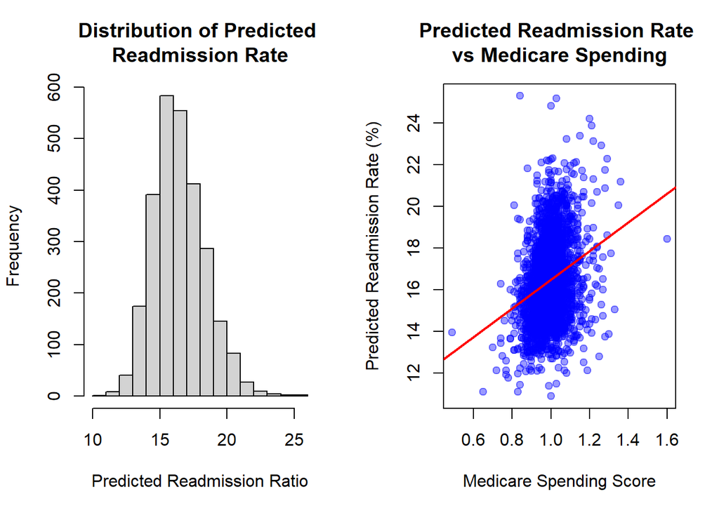

```r
# Your code here.
#DS, EG, MH
par(mfrow= c(1,2))

# Create a histogram of the PredictedReadmissionRate variable
hist(pneumoniaAnalyze$PredictedReadmissionRate,
     main = "Distribution of Predicted \nReadmission Rate",
     xlab = "Predicted Readmission Ratio")


#Medicare Spending and Predicted Readmission Rate
plot(
  pneumoniaAnalyze$'Score_Medicare spending per patient',
  pneumoniaAnalyze$PredictedReadmissionRate,
  main = "Predicted Readmission Rate \nvs Medicare Spending",
  xlab = "Medicare Spending Score",
  ylab = "Predicted Readmission Rate (%)",
  pch = 19,
  col = rgb(0, 0, 1, 0.4)
)

abline(
  lm(PredictedReadmissionRate ~ `Score_Medicare spending per patient`,
     data = pneumoniaAnalyze),
  col = "red",
  lwd = 2
)
```

> The scatterplot shows relationship between `PredictedReadmissionRate` and `Score_Medicare spending per patient`. There appears to be a postive relationship between these features, which is counterintuitive as we expect Readmissions to be smaller with hiugher Medicare spending. This is further investigated below.

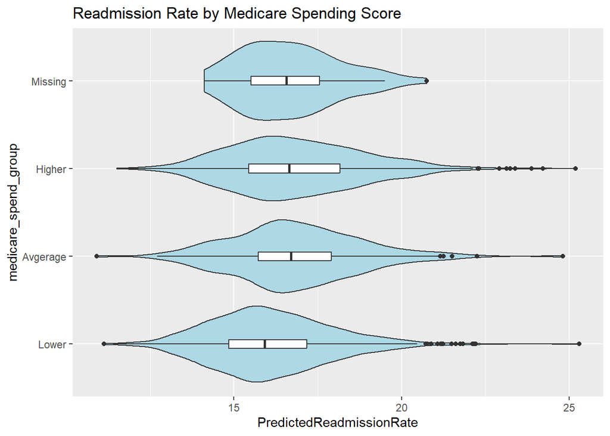

```r
#DS, EG, MH
pneumoniaAnalyze <- pneumoniaAnalyze %>%
  mutate(
      ReturnForPneumonia = case_when(
      `ComparedToNational_Hospital return days for pneumonia patients` == 0 ~ "Average",
      `ComparedToNational_Hospital return days for pneumonia patients` == 1 ~ "Lower",
      `ComparedToNational_Hospital return days for pneumonia patients` == -1 ~ "Higher",
      TRUE ~ "Missing"),
    medicare_spend_group = case_when(
      `Score_Medicare spending per patient` == 1 ~ "Avgerage",
      `Score_Medicare spending per patient` < 1 ~ "Lower",
      `Score_Medicare spending per patient` > 1 ~ "Higher",
      TRUE ~ "Missing"),
    medicare_spend_group = factor(
      medicare_spend_group,
      levels = c("Lower", "Avgerage", "Higher", "Missing")))


#Violin plot showing Predicted Readmission Rate and grouped medicare spending
ggplot(pneumoniaAnalyze,
       aes(x = medicare_spend_group,
           y = PredictedReadmissionRate)) +
  geom_violin(fill = "lightblue") +
  geom_boxplot(width = 0.1) +
  labs(title = "Readmission Rate by Medicare Spending Score") +
  coord_flip()
```

> The violin plots further anaylses the relationship between medicare spending and predicted readmission. `Score_Medicare spending per patient` was broken down in to 3 categories Average if Score was 1, Lower if Score was below 1 and Higher if Score was above 1. Here we can see the Lower spending group having a slightly lower predicted readmission rate than average and higher spend groups.

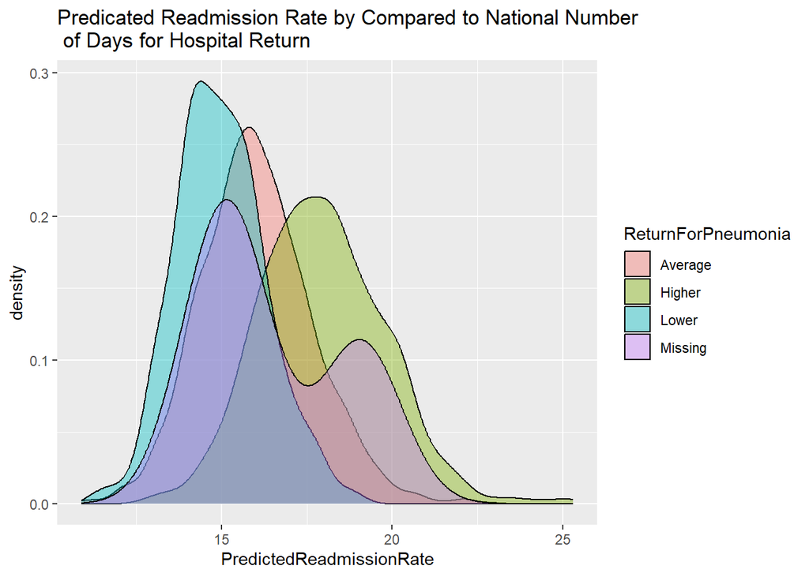

```r
#DS, EG, MH
ggplot(pneumoniaAnalyze,
       aes(
         x = PredictedReadmissionRate,
         fill = ReturnForPneumonia
       )) +
  geom_density(alpha = 0.4) +
  labs(title = "Predicated Readmission Rate by Compared to National Number \n of Days for Hospital Return")
```

> This density plot shows hospitals with a lower `PredictedReadmissionRate` also have a lower `ComparedToNational_Hospital return days for pneumonia patients`. Average and Higher `ComparedToNational_Hospital return days for pneumonia patients` have higher predicte readmission rates, respectively.

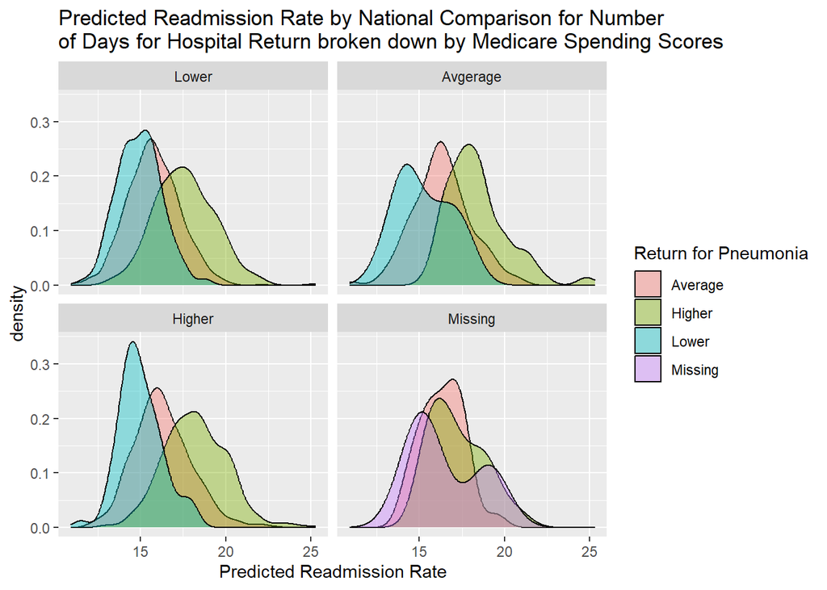

```r
#DS, EG, MH
#faceted density plots showing Predicted Readmission Rate based on National Comparison for Days for Hospital Return broken down by Medicare Spending Scores
ggplot(pneumoniaAnalyze,
       aes(
         x = PredictedReadmissionRate,
         fill = ReturnForPneumonia
       )) +
  geom_density(alpha = 0.4) +
  facet_wrap(~ medicare_spend_group) +
  labs(
    title = "Predicted Readmission Rate by National Comparison for Number\nof Days for Hospital Return broken down by Medicare Spending Scores",
    x = "Predicted Readmission Rate",
    fill = "Return for Pneumonia"
  )
```

> This faceted display breaks down the relationship between `PredictedReadmissionRate` and `ComparedToNational_Hospital return days for pneumonia patients` by Medicare spending score. There does not appear to be any missing medicare spending score date for hospitals that have a lower compared-to-national-return-days. Notably, there are also no missing observations for `ComparedToNational_Hospital return days for pneumonia patients` in any of the remaining plots.

Lastly, make sure to **interpret** your graphic.

> See above.

# References

De Alba, Israel, and Alpesh Amin. 2014. “Pneumonia Readmissions: Risk Factors and Implications.” *Ochsner Journal* 14 (4): 649–54.

R Core Team. 2019. *R: A Language and Environment for Statistical Computing*. Vienna, Austria: R Foundation for Statistical Computing. https://www.R-project.org.

Wickham, Hadley. 2014. “Tidy Data.” *Journal of Statistical Software* 59 (10): 1–23. https://doi.org/10.18637/jss.v059.i10.